# Project_2

### 4.3.2. Диагностика модели

После коррекции модели обязательно необходимо провести повторную диагностику

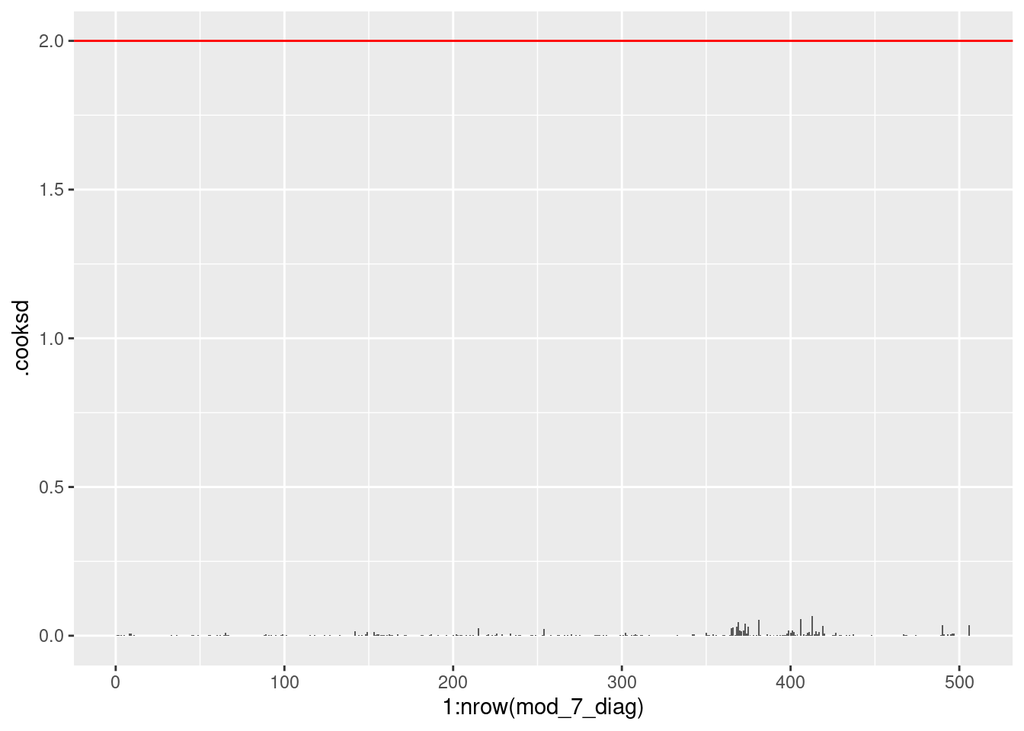

```r
mod_7_diag <- data.frame(fortify(mod_7))

ggplot(mod_7_diag, aes(x = 1:nrow(mod_7_diag), y = .cooksd)) +
  geom_bar(stat = "identity") +
  geom_hline(yintercept = 2, color = "red")
```

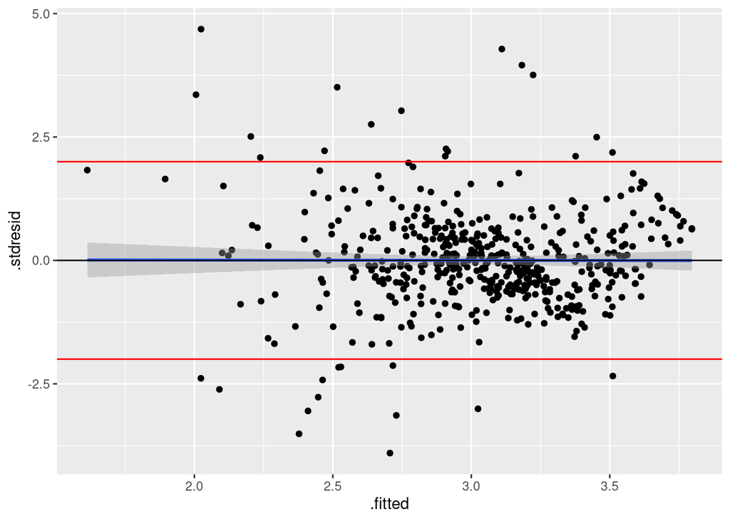

```r
gg_resid_2 <- ggplot(data = mod_7_diag, aes(x = .fitted, y = .stdresid)) +
  geom_point() +
  geom_smooth(method = "lm") +
  geom_hline(yintercept = 0) +
  geom_hline(yintercept = 2, color = "red") +
  geom_hline(yintercept = -2, color = "red")

gg_resid_2
```

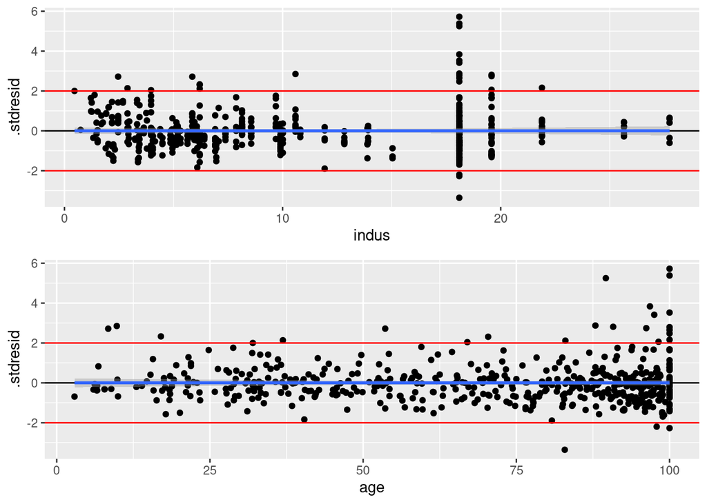

```r
res_4 <- gg_resid + aes(x = indus)
res_5 <- gg_resid + aes(x = age)

grid.arrange(res_4, res_5, nrow = 2)
```

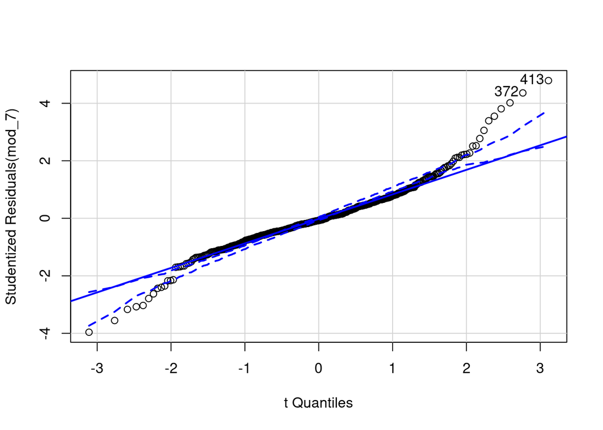

```
## [1] 372 413
```

```r
qqPlot(mod_7)
```

Все еще далеко от идеала. Особенно беспокоит распределение.

### 4.3.3. Удаление выбросов и повышение точности

Раньше я писал о том, что выбросы могут давать такие результаты. Давайте попробуем от них избавиться.

```r
outlierTest(mod_7)
```

```
##      rstudent unadjusted p-value Bonferroni p
## 413  4.789835         2.2201e-06    0.0011234
## 372  4.360927         1.5821e-05    0.0080056
## 373  4.016926         6.8301e-05    0.0345600
## 402 -3.961516         8.5631e-05    0.0433300
```

```r
data_mod = data[-c(413,372, 373, 402),,drop=T]
row.names(data_mod)=1:nrow(data_mod)
```

Проверим результаты:

```r
mod_8 <- lm(formula = log(medv) ~ crim + zn + chas + rm + dis + rad +
    ptratio + black + lstat + tax + nox, data = data_mod)
summary(mod_8)
```

```
##
## Call:
## lm(formula = log(medv) ~ crim + zn + chas + rm + dis + rad +
##     ptratio + black + lstat + tax + nox, data = data_mod)
##
## Residuals:
##      Min       1Q   Median       3Q      Max
## -0.66088 -0.09211 -0.01470  0.09055  0.73182
##
## Coefficients:
##               Estimate Std. Error t value Pr(>|t|)
## (Intercept)  3.7729058  0.2037377  18.518  < 2e-16 ***
## crim        -0.0100474  0.0012193  -8.240 1.63e-15 ***
## zn           0.0012660  0.0005201   2.434 0.015287 *
## chas1        0.0805478  0.0324624   2.481 0.013431 *
## rm           0.1009601  0.0154629   6.529 1.68e-10 ***
## dis         -0.0483810  0.0071018  -6.812 2.86e-11 ***
## rad2         0.0938309  0.0545916   1.719 0.086295 .
## rad3         0.1754435  0.0497904   3.524 0.000466 ***
## rad4         0.1066492  0.0441979   2.413 0.016193 *
## rad5         0.1324187  0.0450433   2.940 0.003442 **
## rad6         0.0918239  0.0542706   1.692 0.091298 .
## rad7         0.2009424  0.0586081   3.429 0.000659 ***
## rad8         0.1879373  0.0554201   3.391 0.000753 ***
## rad24        0.3197577  0.0654943   4.882 1.43e-06 ***
## ptratio     -0.0358585  0.0053620  -6.688 6.29e-11 ***
## black        0.0004966  0.0001003   4.953 1.01e-06 ***
## lstat       -0.0279784  0.0017901 -15.629  < 2e-16 ***
## tax         -0.0004390  0.0001315  -3.340 0.000903 ***
## nox         -0.6007719  0.1358272  -4.423 1.20e-05 ***
## ---
## Signif. codes:  0 '***' 0.001 '**' 0.01 '*' 0.05 '.' 0.1 ' ' 1
##
## Residual standard error: 0.1752 on 483 degrees of freedom
## Multiple R-squared:  0.8185, Adjusted R-squared:  0.8117
## F-statistic:   121 on 18 and 483 DF,  p-value: < 2.2e-16
```

Выиграли еще почти 3% точности(adj.R-squared =0.8117).

Итого формула на данный момент: **log(medv) = 3.773 - 0.01 * crim + 0.001 * zn + 0.08 * chas + 0.1 * rm - 0.036 * ptratio + 0.0005 * black - 0.028 * lstat - 0.60 * nox - 0.0005 * tax + 0.09 * rad2 + 0.176 * rad3 + 0.106 * rad4 + 0.132 * rad5 + 0.09 * rad6 + 0.2 * rad7 + 0.187 * rad8 + 0.32 * rad24 - 0.049 * dis**

Проведем диагностику модели:

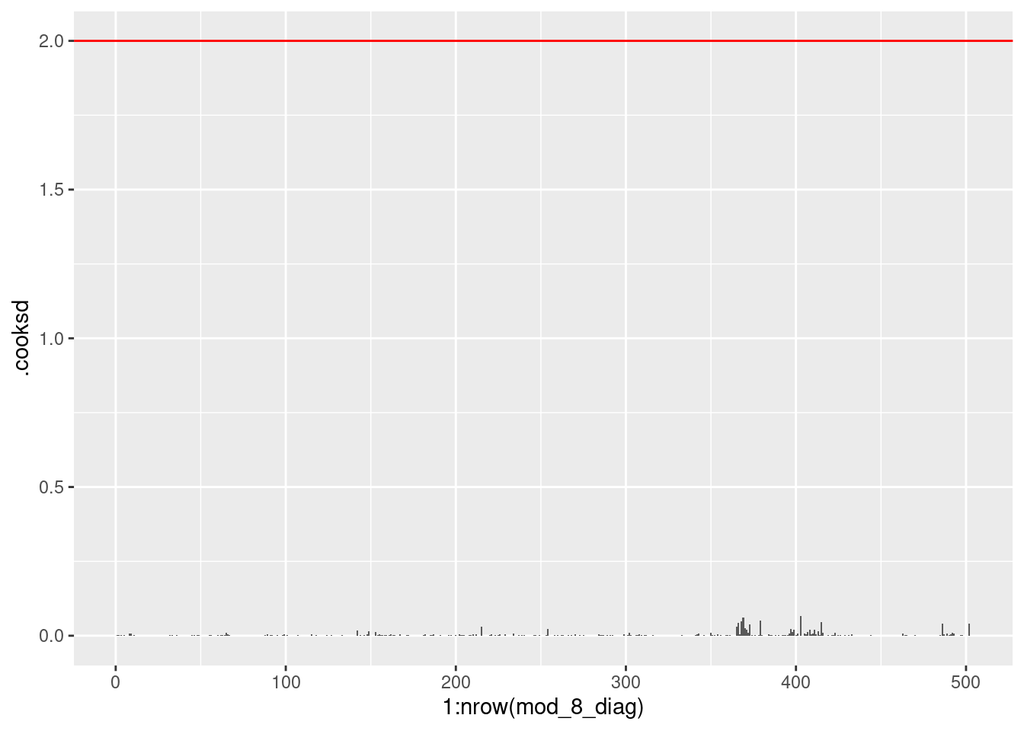

```r
mod_8_diag <- data.frame(fortify(mod_8))

ggplot(mod_8_diag, aes(x = 1:nrow(mod_8_diag), y = .cooksd)) +
  geom_bar(stat = "identity") +
  geom_hline(yintercept = 2, color = "red")
```

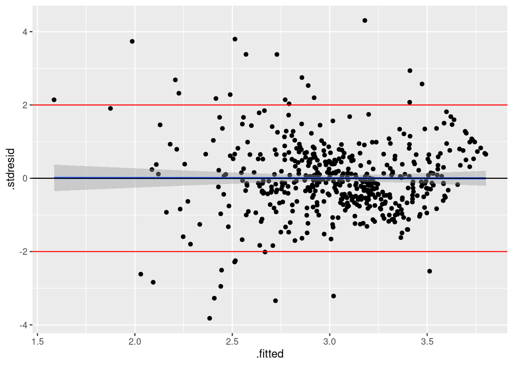

```r
gg_resid_3 <- ggplot(data = mod_8_diag, aes(x = .fitted, y = .stdresid)) +
  geom_point() +
  geom_smooth(method = "lm") +
  geom_hline(yintercept = 0) +
  geom_hline(yintercept = 2, color = "red") +
  geom_hline(yintercept = -2, color = "red")

gg_resid_3
```

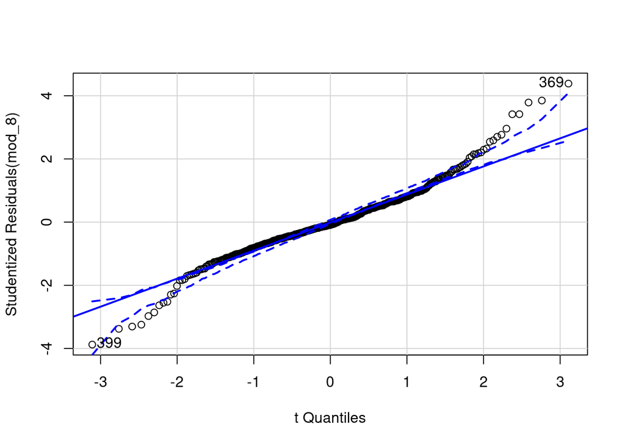

```
## [1] 369 399
```

```r
qqPlot(mod_8)
```

QQ-plot все еще далек от идеала, но лучше, чем было до этого. Попробуем еще поискать выбросы?

```r
outlierTest(mod_8)
```

```
##     rstudent unadjusted p-value Bonferroni p
## 369 4.385718         1.4207e-05    0.0071318
```

```r
data_mod2 <- data_mod[-c(369),,drop=T]
row.names(data_mod2)=1:nrow(data_mod2)
mod_9 <- lm(formula = log(medv) ~ crim + chas + rm + ptratio + black +
    lstat + nox + tax + rad + dis, data = data_mod2)
summary(mod_9)
```

```
##
## Call:
## lm(formula = log(medv) ~ crim + chas + rm + ptratio + black +
##     lstat + nox + tax + rad + dis, data = data_mod2)
##
## Residuals:
##      Min       1Q   Median       3Q      Max
## -0.66481 -0.09394 -0.01201  0.09396  0.65816
##
## Coefficients:
##               Estimate Std. Error t value Pr(>|t|)
## (Intercept)  3.702e+00  2.018e-01  18.346  < 2e-16 ***
## crim        -9.661e-03  1.200e-03  -8.051 6.44e-15 ***
## chas1        8.267e-02  3.202e-02   2.582  0.01012 *
## rm           1.190e-01  1.530e-02   7.774 4.62e-14 ***
## ptratio     -4.000e-02  4.915e-03  -8.138 3.43e-15 ***
## black        4.949e-04  9.888e-05   5.005 7.83e-07 ***
## lstat       -2.650e-02  1.797e-03 -14.750  < 2e-16 ***
## nox         -6.175e-01  1.335e-01  -4.626 4.79e-06 ***
## tax         -4.067e-04  1.288e-04  -3.158  0.00169 **
## rad2         8.444e-02  5.373e-02   1.571  0.11674
## rad3         1.578e-01  4.859e-02   3.248  0.00124 **
## rad4         9.783e-02  4.344e-02   2.252  0.02479 *
## rad5         1.148e-01  4.374e-02   2.624  0.00897 **
## rad6         7.925e-02  5.319e-02   1.490  0.13689
## rad7         1.794e-01  5.733e-02   3.130  0.00185 **
## rad8         1.560e-01  5.340e-02   2.921  0.00365 **
## rad24        2.952e-01  6.449e-02   4.577 6.00e-06 ***
## dis         -3.773e-02  6.121e-03  -6.164 1.50e-09 ***
## ---
## Signif. codes:  0 '***' 0.001 '**' 0.01 '*' 0.05 '.' 0.1 ' ' 1
##
## Residual standard error: 0.1728 on 483 degrees of freedom
## Multiple R-squared:  0.8218, Adjusted R-squared:  0.8155
## F-statistic:   131 on 17 and 483 DF,  p-value: < 2.2e-16
```

Добавили еще немного мощности. Но прирост краней незначителен(adj.R-su=quared = 0.816).

Для очистки совести давайте посмотрим на выбросы еще раз:

```r
outlierTest(mod_9)
```

```
##      rstudent unadjusted p-value Bonferroni p
## 372  3.959819         8.6321e-05     0.043247
## 398 -3.955638         8.7796e-05     0.043986
```

```r
data_mod3 <- data_mod2[-c(372,398),,drop=T]
row.names(data_mod3)=1:nrow(data_mod3)
mod_10 <- lm(formula = log(medv) ~ crim + chas + rm + ptratio + black +
    lstat + nox + tax + rad + dis, data = data_mod3)
summary(mod_10)
```

```
##
## Call:
## lm(formula = log(medv) ~ crim + chas + rm + ptratio + black +
##     lstat + nox + tax + rad + dis, data = data_mod3)
##
## Residuals:
##      Min       1Q   Median       3Q      Max
## -0.56153 -0.09300 -0.01110  0.09403  0.64228
##
## Coefficients:
##               Estimate Std. Error t value Pr(>|t|)
## (Intercept)  3.618e+00  1.965e-01  18.418  < 2e-16 ***
## crim        -9.340e-03  1.169e-03  -7.993 9.86e-15 ***
## chas1        8.191e-02  3.108e-02   2.635 0.008685 **
## rm           1.253e-01  1.490e-02   8.411 4.68e-16 ***
## ptratio     -3.900e-02  4.778e-03  -8.162 2.91e-15 ***
## black        4.974e-04  9.663e-05   5.148 3.85e-07 ***
## lstat       -2.678e-02  1.760e-03 -15.215  < 2e-16 ***
## nox         -5.801e-01  1.299e-01  -4.464 1.00e-05 ***
## tax         -4.017e-04  1.250e-04  -3.214 0.001398 **
## rad2         8.626e-02  5.217e-02   1.653 0.098894 .
## rad3         1.598e-01  4.717e-02   3.387 0.000766 ***
## rad4         1.002e-01  4.218e-02   2.375 0.017936 *
## rad5         1.159e-01  4.247e-02   2.730 0.006566 **
## rad6         8.302e-02  5.165e-02   1.607 0.108602
## rad7         1.784e-01  5.565e-02   3.205 0.001440 **
## rad8         1.539e-01  5.184e-02   2.968 0.003144 **
## rad24        2.897e-01  6.263e-02   4.625 4.81e-06 ***
## dis         -3.663e-02  5.947e-03  -6.160 1.54e-09 ***
## ---
## Signif. codes:  0 '***' 0.001 '**' 0.01 '*' 0.05 '.' 0.1 ' ' 1
##
## Residual standard error: 0.1678 on 481 degrees of freedom
## Multiple R-squared:  0.8287, Adjusted R-squared:  0.8227
## F-statistic: 136.9 on 17 and 481 DF,  p-value: < 2.2e-16
```